# 25 seasons of the Premier League, in plain SQL

**Data:** match results from [football-data.co.uk](https://www.football-data.co.uk/englandm.php), free for personal use. Run `python build_db.py` once to download the 25 season files (about 3 MB) into a SQLite database, then point `PL_DB` at that file.

**Reading the data.** Tables use 3 points for a win and rank by points, then goal difference (which is how the 2011/12 title was decided). Odds are William Hill's pre-match prices and are missing for about 200 matches. Team names are the short names used in the source (for example "Man United").

```python
import os
import sqlite3
from pathlib import Path

import matplotlib.pyplot as plt
import numpy as np
import pandas as pd

DB_PATH = Path(os.environ.get("PL_DB", "premier_league.db"))
AMBER, BLUE, GREY = "#e8a33d", "#2b6cb0", "#a0aec0"
plt.rcParams.update({"axes.spines.top": False, "axes.spines.right": False, "axes.grid": True,
                     "grid.alpha": 0.25, "figure.dpi": 110})
pd.set_option("display.width", 120)
pd.set_option("display.max_columns", 20)

con = sqlite3.connect(DB_PATH)


def q(sql):
    """Run a query and return the result as a DataFrame."""
    return pd.read_sql_query(sql, con)
```

## 0. What is in the database?

```python
tables = q("SELECT name FROM sqlite_master WHERE type = 'table' ORDER BY name").name
pd.DataFrame({"table": tables,
              "rows": [con.execute(f'SELECT COUNT(*) FROM "{t}"').fetchone()[0] for t in tables]})
```

|  | table | rows |
| --- | --- | --- |
| 0 | matches | 9500 |

## 1. How big is home advantage, and what happened without crowds?

Averaging a 0/1 comparison (`result = 'H'`) per season gives the share of home wins, draws and away wins. 2020/21 was played mostly behind closed doors.

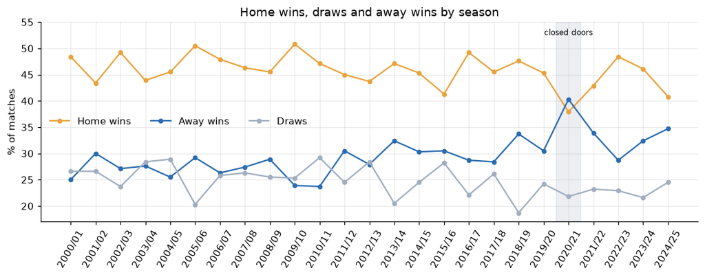

|  | season | matches | home_win_pct | draw_pct | away_win_pct | goals_per_match | home_goal_edge |
| --- | --- | --- | --- | --- | --- | --- | --- |
| 0 | 2000/01 | 380 | 48.4 | 26.6 | 25.0 | 2.61 | 0.48 |
| 10 | 2010/11 | 380 | 47.1 | 29.2 | 23.7 | 2.80 | 0.45 |
| 20 | 2020/21 | 380 | 37.9 | 21.8 | 40.3 | 2.69 | 0.01 |
| 21 | 2021/22 | 380 | 42.9 | 23.2 | 33.9 | 2.82 | 0.21 |

```python
home = q("""
SELECT season,
       COUNT(*)                                             AS matches,
       ROUND(100.0 * AVG(result = 'H'), 1)                  AS home_win_pct,
       ROUND(100.0 * AVG(result = 'D'), 1)                  AS draw_pct,
       ROUND(100.0 * AVG(result = 'A'), 1)                  AS away_win_pct,
       ROUND(AVG(home_goals + away_goals), 2)               AS goals_per_match,
       ROUND(AVG(home_goals) - AVG(away_goals), 2)          AS home_goal_edge
FROM matches
GROUP BY season
ORDER BY season
""")

fig, ax = plt.subplots(figsize=(10, 4))
ax.plot(home.season, home.home_win_pct, marker="o", ms=4, color=AMBER, label="Home wins")
ax.plot(home.season, home.away_win_pct, marker="o", ms=4, color=BLUE, label="Away wins")
ax.plot(home.season, home.draw_pct, marker="o", ms=4, color=GREY, label="Draws")
i = home.season.tolist().index("2020/21")
ax.axvspan(i - 0.5, i + 0.5, color=GREY, alpha=0.2)
ax.text(i, 52.5, "closed doors", ha="center", fontsize=8)
ax.set_ylim(17, 55)
ax.set_ylabel("% of matches")
ax.tick_params(axis="x", rotation=60)
ax.set_title("Home wins, draws and away wins by season")
ax.legend(frameon=False, ncol=3)
fig.tight_layout()
plt.show()
home.iloc[[0, 10, 20, -4]]
```

## 2. Who won the league, and by how much?

A league table is not stored anywhere, so it is rebuilt: each match becomes two rows (one per team) with `UNION ALL`, points and goals are summed per team and season, `ROW_NUMBER()` ranks the table and `LEAD()` looks at the team directly below to get the runner-up and the margin.

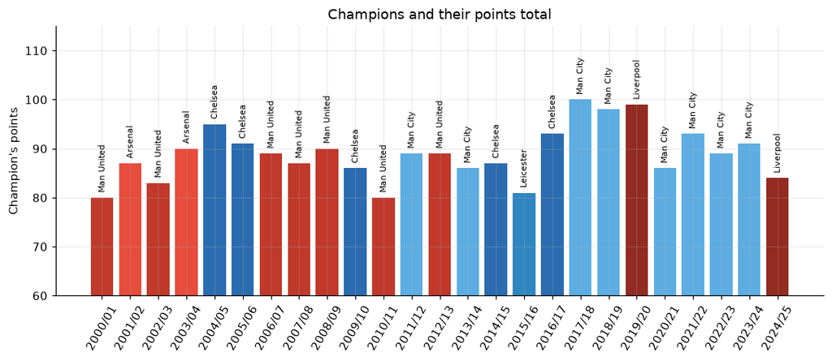

| champion | titles |
| --- | --- |
| Man City | 8 |
| Man United | 7 |
| Chelsea | 5 |
| Arsenal | 2 |
| Liverpool | 2 |
| Leicester | 1 |

```python
champions = q("""
WITH team_matches AS (
    SELECT season, match_date, home_team AS team, away_team AS opponent, 1 AS is_home,
           home_goals AS gf, away_goals AS ga, ht_home_goals AS ht_gf, ht_away_goals AS ht_ga,
           CASE result WHEN 'H' THEN 3 WHEN 'D' THEN 1 ELSE 0 END AS points
    FROM matches
    UNION ALL
    SELECT season, match_date, away_team, home_team, 0,
           away_goals, home_goals, ht_away_goals, ht_home_goals,
           CASE result WHEN 'A' THEN 3 WHEN 'D' THEN 1 ELSE 0 END
    FROM matches
),
table_ AS (
    SELECT season, team, SUM(points) AS pts, SUM(gf) - SUM(ga) AS gd
    FROM team_matches
    GROUP BY season, team
),
ranked AS (
    SELECT *,
           ROW_NUMBER() OVER (PARTITION BY season ORDER BY pts DESC, gd DESC) AS pos,
           LEAD(team)   OVER (PARTITION BY season ORDER BY pts DESC, gd DESC) AS runner_up,
           LEAD(pts)    OVER (PARTITION BY season ORDER BY pts DESC, gd DESC) AS runner_up_pts
    FROM table_
)
SELECT season, team AS champion, pts AS points, gd AS goal_difference,
       runner_up, pts - runner_up_pts AS margin
FROM ranked
WHERE pos = 1
ORDER BY season
""")

fig, ax = plt.subplots(figsize=(10, 4.4))
colors = {"Man United": "#c0392b", "Chelsea": BLUE, "Man City": "#5dade2", "Arsenal": "#e74c3c",
          "Liverpool": "#922b21", "Leicester": "#2e86c1"}
ax.bar(champions.season, champions.points, color=[colors.get(t, GREY) for t in champions.champion])
for x, (t, p) in enumerate(zip(champions.champion, champions.points)):
    ax.text(x, p + 1, t, rotation=90, ha="center", va="bottom", fontsize=7)
ax.set_ylim(60, 115)
ax.set_ylabel("Champion's points")
ax.tick_params(axis="x", rotation=60)
ax.set_title("Champions and their points total")
fig.tight_layout()
plt.show()
champions.groupby("champion").size().sort_values(ascending=False).to_frame("titles")
```

## 3. How did Leicester's 2015/16 title race unfold?

A **running total** (`SUM(points) OVER (PARTITION BY team ORDER BY match_date)`) turns each team's results into points after every match. `ROW_NUMBER()` numbers the matches as matchweeks, and a small CTE keeps only the top three finishers.

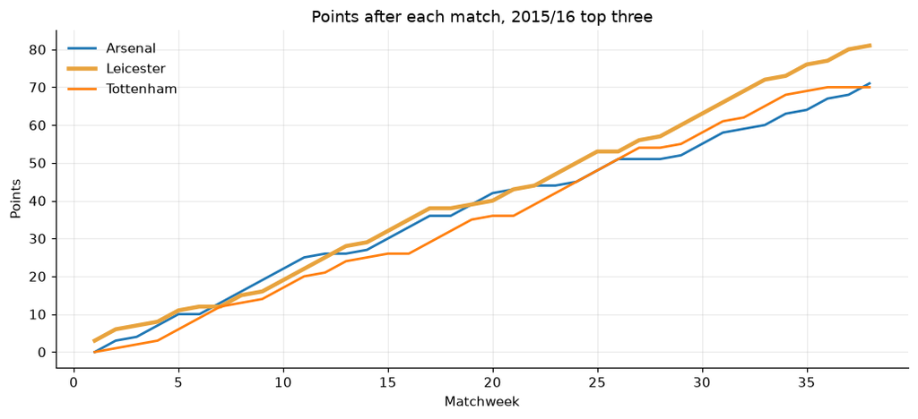

|  | matchweek | team | cumulative_points |
| --- | --- | --- | --- |
| 37 | 38 | Arsenal | 71 |
| 75 | 38 | Leicester | 81 |
| 113 | 38 | Tottenham | 70 |

```python
race = q("""
WITH team_matches AS (
    SELECT season, match_date, home_team AS team, away_team AS opponent, 1 AS is_home,
           home_goals AS gf, away_goals AS ga, ht_home_goals AS ht_gf, ht_away_goals AS ht_ga,
           CASE result WHEN 'H' THEN 3 WHEN 'D' THEN 1 ELSE 0 END AS points
    FROM matches
    UNION ALL
    SELECT season, match_date, away_team, home_team, 0,
           away_goals, home_goals, ht_away_goals, ht_home_goals,
           CASE result WHEN 'A' THEN 3 WHEN 'D' THEN 1 ELSE 0 END
    FROM matches
),
games AS (
    SELECT team, points,
           ROW_NUMBER() OVER (PARTITION BY team ORDER BY match_date)        AS matchweek,
           SUM(points)  OVER (PARTITION BY team ORDER BY match_date)        AS cumulative_points
    FROM team_matches
    WHERE season = '2015/16'
),
top3 AS (
    SELECT team FROM games WHERE matchweek = 38 ORDER BY cumulative_points DESC LIMIT 3
)
SELECT matchweek, team, cumulative_points
FROM games
WHERE team IN (SELECT team FROM top3)
ORDER BY team, matchweek
""")

fig, ax = plt.subplots(figsize=(9.5, 4.4))
for team, g in race.groupby("team"):
    ax.plot(g.matchweek, g.cumulative_points, lw=3 if team == "Leicester" else 1.8,
            color=AMBER if team == "Leicester" else None, label=team)
ax.set_xlabel("Matchweek")
ax.set_ylabel("Points")
ax.set_title("Points after each match, 2015/16 top three")
ax.legend(frameon=False)
fig.tight_layout()
plt.show()
race[race.matchweek == 38]
```

## 4. What were the longest unbeaten runs?

A **gaps-and-islands** query: every team's matches are numbered in date order, and the difference between that number and the number *within* the "not lost" matches stays constant for as long as an unbeaten run lasts, so grouping by it collapses each run into one row. Runs are counted across seasons.

```python
streaks = q("""
WITH team_matches AS (
    SELECT season, match_date, home_team AS team, away_team AS opponent, 1 AS is_home,
           home_goals AS gf, away_goals AS ga, ht_home_goals AS ht_gf, ht_away_goals AS ht_ga,
           CASE result WHEN 'H' THEN 3 WHEN 'D' THEN 1 ELSE 0 END AS points
    FROM matches
    UNION ALL
    SELECT season, match_date, away_team, home_team, 0,
           away_goals, home_goals, ht_away_goals, ht_home_goals,
           CASE result WHEN 'A' THEN 3 WHEN 'D' THEN 1 ELSE 0 END
    FROM matches
),
ordered AS (
    SELECT team, match_date, points > 0 AS unbeaten,
           ROW_NUMBER() OVER (PARTITION BY team ORDER BY match_date) AS game_no
    FROM team_matches
),
numbered AS (
    SELECT *, ROW_NUMBER() OVER (PARTITION BY team, unbeaten ORDER BY match_date) AS flag_no
    FROM ordered
)
SELECT team,
       COUNT(*)        AS matches_unbeaten,
       MIN(match_date) AS from_date,
       MAX(match_date) AS to_date
FROM numbered
WHERE unbeaten = 1
GROUP BY team, game_no - flag_no
ORDER BY matches_unbeaten DESC, from_date
LIMIT 8
""")

streaks
```

|  | team | matches_unbeaten | from_date | to_date |
| --- | --- | --- | --- | --- |
| 0 | Arsenal | 49 | 2003-05-07 | 2004-10-16 |
| 1 | Liverpool | 44 | 2019-01-12 | 2020-02-24 |
| 2 | Chelsea | 40 | 2004-10-23 | 2005-10-29 |
| 3 | Man City | 32 | 2023-12-10 | 2024-10-26 |
| 4 | Arsenal | 30 | 2001-12-23 | 2002-10-06 |
| 5 | Man City | 30 | 2017-04-08 | 2018-01-02 |
| 6 | Chelsea | 29 | 2007-12-23 | 2008-10-18 |
| 7 | Man United | 29 | 2010-04-11 | 2011-02-01 |

## 5. Who comes back from behind?

With each match in two rows, the half-time score from the team's point of view (`ht_gf`, `ht_ga`) can be compared with the final result. Conditional sums count comeback wins (behind at half-time, won) and blown leads (ahead at half-time, lost) for the teams with at least ten seasons of data.

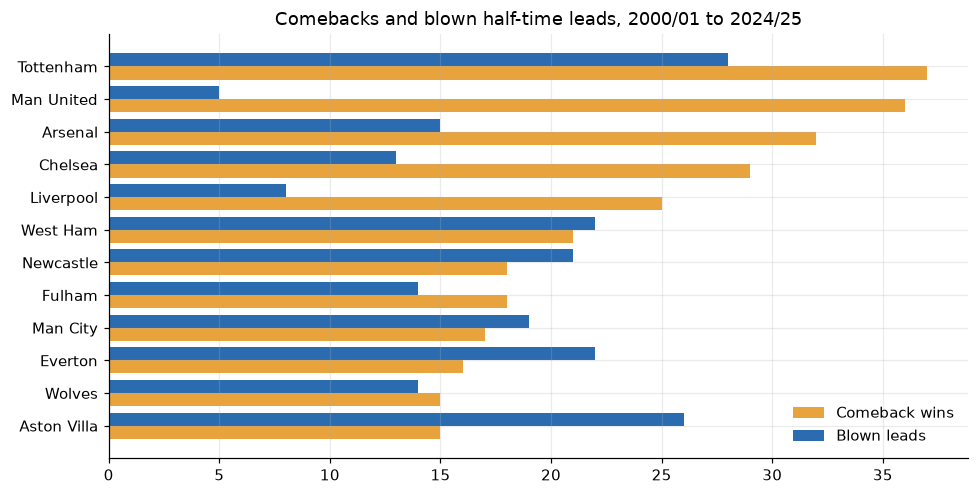

|  | team | matches | comeback_wins | blown_leads | net |
| --- | --- | --- | --- | --- | --- |
| 0 | Tottenham | 950 | 37 | 28 | 9 |
| 1 | Man United | 950 | 36 | 5 | 31 |
| 2 | Arsenal | 950 | 32 | 15 | 17 |
| 3 | Chelsea | 950 | 29 | 13 | 16 |
| 4 | Liverpool | 950 | 25 | 8 | 17 |
| 5 | West Ham | 836 | 21 | 22 | -1 |
| 6 | Newcastle | 874 | 18 | 21 | -3 |
| 7 | Fulham | 684 | 18 | 14 | 4 |
| 8 | Man City | 912 | 17 | 19 | -2 |
| 9 | Everton | 950 | 16 | 22 | -6 |
| 10 | Wolves | 418 | 15 | 14 | 1 |
| 11 | Aston Villa | 836 | 15 | 26 | -11 |

```python
comebacks = q("""
WITH team_matches AS (
    SELECT season, match_date, home_team AS team, away_team AS opponent, 1 AS is_home,
           home_goals AS gf, away_goals AS ga, ht_home_goals AS ht_gf, ht_away_goals AS ht_ga,
           CASE result WHEN 'H' THEN 3 WHEN 'D' THEN 1 ELSE 0 END AS points
    FROM matches
    UNION ALL
    SELECT season, match_date, away_team, home_team, 0,
           away_goals, home_goals, ht_away_goals, ht_home_goals,
           CASE result WHEN 'A' THEN 3 WHEN 'D' THEN 1 ELSE 0 END
    FROM matches
)
SELECT team,
       COUNT(*)                                               AS matches,
       SUM(ht_gf < ht_ga AND points = 3)                      AS comeback_wins,
       SUM(ht_gf > ht_ga AND points = 0)                      AS blown_leads,
       SUM(ht_gf < ht_ga AND points = 3)
         - SUM(ht_gf > ht_ga AND points = 0)                  AS net
FROM team_matches
GROUP BY team
HAVING matches >= 380
ORDER BY comeback_wins DESC
LIMIT 12
""")

fig, ax = plt.subplots(figsize=(9, 4.6))
y = np.arange(len(comebacks))
ax.barh(y + 0.2, comebacks.comeback_wins, height=0.4, color=AMBER, label="Comeback wins")
ax.barh(y - 0.2, comebacks.blown_leads, height=0.4, color=BLUE, label="Blown leads")
ax.set_yticks(y, comebacks.team)
ax.invert_yaxis()
ax.set_title("Comebacks and blown half-time leads, 2000/01 to 2024/25")
ax.legend(frameon=False)
fig.tight_layout()
plt.show()
comebacks
```

## 6. Are the bookmakers' odds well calibrated?

Odds convert to probabilities by taking `1/odds` and rescaling the three outcomes so they sum to 100% (removing the bookmaker's margin). Grouping matches by the implied chance of a home win and comparing it with how often the home team really won is a calibration check.

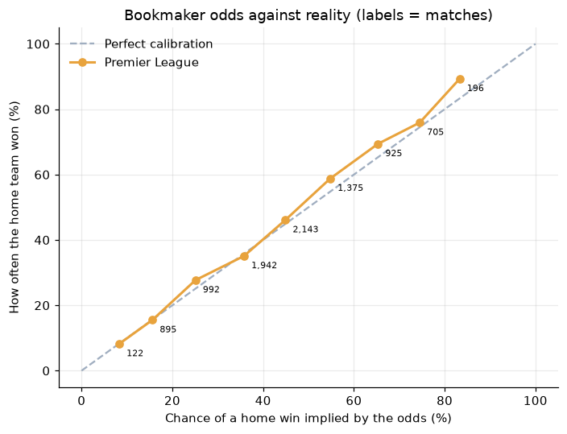

|  | bucket_from_pct | matches | predicted_home_win_pct | actual_home_win_pct |
| --- | --- | --- | --- | --- |
| 0 | 0 | 122 | 8.3 | 8.2 |
| 1 | 10 | 895 | 15.6 | 15.5 |
| 2 | 20 | 992 | 25.1 | 27.7 |
| 3 | 30 | 1942 | 35.8 | 35.1 |
| 4 | 40 | 2143 | 44.9 | 46.1 |
| 5 | 50 | 1375 | 54.8 | 58.8 |
| 6 | 60 | 925 | 65.3 | 69.4 |
| 7 | 70 | 705 | 74.5 | 75.9 |
| 8 | 80 | 196 | 83.3 | 89.3 |

```python
odds = q("""
WITH probs AS (
    SELECT result,
           (1.0 / odds_home) / (1.0 / odds_home + 1.0 / odds_draw + 1.0 / odds_away) AS p_home
    FROM matches
    WHERE odds_home IS NOT NULL AND odds_draw IS NOT NULL AND odds_away IS NOT NULL
)
SELECT MIN(CAST(p_home * 10 AS INT), 8) * 10                  AS bucket_from_pct,
       COUNT(*)                                               AS matches,
       ROUND(100.0 * AVG(p_home), 1)                          AS predicted_home_win_pct,
       ROUND(100.0 * AVG(result = 'H'), 1)                    AS actual_home_win_pct
FROM probs
GROUP BY bucket_from_pct
ORDER BY bucket_from_pct
""")

fig, ax = plt.subplots(figsize=(6.5, 5))
ax.plot([0, 100], [0, 100], color=GREY, ls="--", label="Perfect calibration")
ax.plot(odds.predicted_home_win_pct, odds.actual_home_win_pct, marker="o", color=AMBER, lw=2, label="Premier League")
for _, r in odds.iterrows():
    ax.annotate(f"{int(r.matches):,}", (r.predicted_home_win_pct, r.actual_home_win_pct), textcoords="offset points",
                xytext=(6, -10), fontsize=7)
ax.set_xlabel("Chance of a home win implied by the odds (%)")
ax.set_ylabel("How often the home team won (%)")
ax.set_title("Bookmaker odds against reality (labels = matches)")
ax.legend(frameon=False)
fig.tight_layout()
plt.show()
odds
```

## 7. Which referees show the most cards?

Per referee with at least 150 matches: cards per match (yellow plus red), fouls per match and the difference between home and away yellow cards, a rough check for home bias.

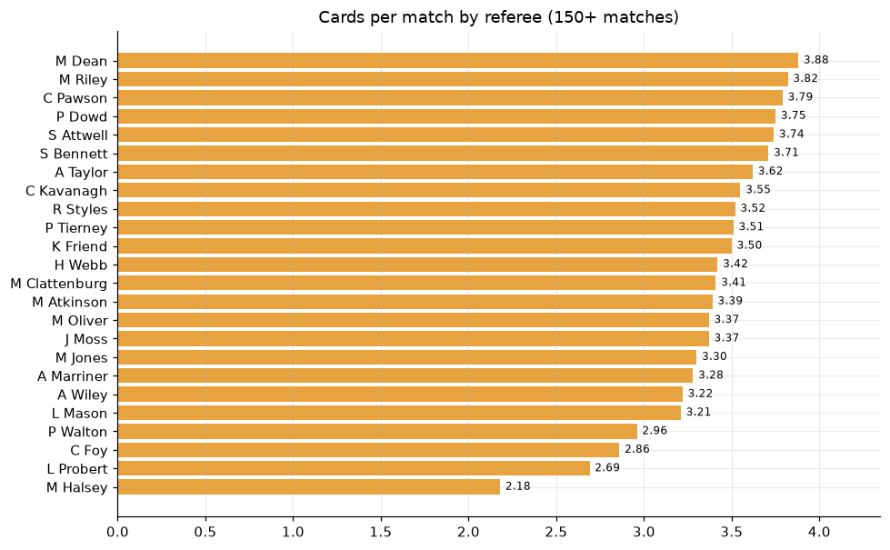

|  | count | mean | std | min | 25% | 50% | 75% | max |
| --- | --- | --- | --- | --- | --- | --- | --- | --- |
| home_minus_away_yellows | 24.0 | -0.32 | 0.15 | -0.64 | -0.42 | -0.3 | -0.2 | -0.07 |

```python
referees = q("""
SELECT referee,
       COUNT(*)                                                     AS matches,
       ROUND(AVG(home_yellow + away_yellow + home_red + away_red), 2) AS cards_per_match,
       ROUND(AVG(home_fouls + away_fouls), 1)                       AS fouls_per_match,
       ROUND(AVG(home_yellow) - AVG(away_yellow), 2)                AS home_minus_away_yellows
FROM matches
WHERE referee IS NOT NULL
GROUP BY referee
HAVING matches >= 150
ORDER BY cards_per_match DESC
""")

fig, ax = plt.subplots(figsize=(9, 5.6))
ax.barh(referees.referee[::-1], referees.cards_per_match[::-1], color=AMBER)
for y, v in enumerate(referees.cards_per_match[::-1]):
    ax.text(v + 0.03, y, f"{v:.2f}", va="center", fontsize=8)
ax.set_xlim(0, referees.cards_per_match.max() * 1.12)
ax.set_title("Cards per match by referee (150+ matches)")
fig.tight_layout()
plt.show()
referees[["referee", "home_minus_away_yellows"]].describe().round(2).T
```

## 8. Which teams depend most on their own ground?

Home and away points per game are computed side by side with conditional aggregation over the two-rows-per-match table; the gap between them is the team's home bonus. Only teams with at least five seasons of home games are listed.

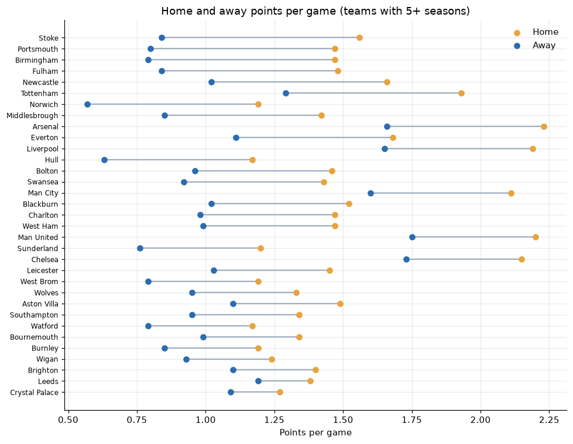

|  | team | home_games | home_points_per_game | away_points_per_game | home_bonus |
| --- | --- | --- | --- | --- | --- |
| 0 | Stoke | 190 | 1.56 | 0.84 | 0.72 |
| 1 | Portsmouth | 133 | 1.47 | 0.80 | 0.68 |
| 2 | Birmingham | 133 | 1.47 | 0.79 | 0.68 |
| 3 | Fulham | 342 | 1.48 | 0.84 | 0.65 |
| 4 | Tottenham | 475 | 1.93 | 1.29 | 0.64 |

```python
form = q("""
WITH team_matches AS (
    SELECT season, match_date, home_team AS team, away_team AS opponent, 1 AS is_home,
           home_goals AS gf, away_goals AS ga, ht_home_goals AS ht_gf, ht_away_goals AS ht_ga,
           CASE result WHEN 'H' THEN 3 WHEN 'D' THEN 1 ELSE 0 END AS points
    FROM matches
    UNION ALL
    SELECT season, match_date, away_team, home_team, 0,
           away_goals, home_goals, ht_away_goals, ht_home_goals,
           CASE result WHEN 'A' THEN 3 WHEN 'D' THEN 1 ELSE 0 END
    FROM matches
)
SELECT team,
       SUM(is_home)                                                       AS home_games,
       ROUND(1.0 * SUM(CASE WHEN is_home = 1 THEN points END) / SUM(is_home), 2)     AS home_points_per_game,
       ROUND(1.0 * SUM(CASE WHEN is_home = 0 THEN points END) / SUM(1 - is_home), 2) AS away_points_per_game,
       ROUND(1.0 * SUM(CASE WHEN is_home = 1 THEN points END) / SUM(is_home)
           - 1.0 * SUM(CASE WHEN is_home = 0 THEN points END) / SUM(1 - is_home), 2) AS home_bonus
FROM team_matches
GROUP BY team
HAVING home_games >= 95
ORDER BY home_bonus DESC
""")

d = form.sort_values("home_bonus")
fig, ax = plt.subplots(figsize=(9, 7))
y = np.arange(len(d))
ax.hlines(y, d.away_points_per_game, d.home_points_per_game, color=GREY)
ax.scatter(d.home_points_per_game, y, color=AMBER, label="Home", zorder=3)
ax.scatter(d.away_points_per_game, y, color=BLUE, label="Away", zorder=3)
ax.set_yticks(y, d.team, fontsize=8)
ax.set_xlabel("Points per game")
ax.set_title("Home and away points per game (teams with 5+ seasons)")
ax.legend(frameon=False)
fig.tight_layout()
plt.show()
form.head(5)
```

## What the queries say

- **Home advantage is real, and disappeared without crowds.** Over 25 seasons the home team wins 45.8% of matches. In 2020/21, mostly played behind closed doors, home wins fell to 37.9% and away wins rose to 40.3%, the only season in which visitors won more often than hosts. In 2024/25 home wins (40.8%) were the second-lowest share of the 25 seasons, with 34.7% away wins.
- **Six clubs shared the 25 titles.** Manchester City won 8 of the 25 titles, Manchester United 7, Chelsea 5, Arsenal 2, Liverpool 2 and Leicester 1. The lowest winning total was 80 points (Manchester United in both 2000/01 and 2010/11), the highest 100 (Manchester City, 2017/18).
- **Some titles were decided by almost nothing.** In 2011/12 Manchester City and Manchester United finished level on 89 points and City won on goal difference (a margin of 0). Chelsea won in 2009/10 by a single point and City in 2018/19 by one. The biggest margins were City's 19 points in 2017/18 and Liverpool's 18 in 2019/20.
- **Leicester's 2015/16 title was not a photo finish.** They finished on 81 points, ten clear of Arsenal (71) and eleven clear of Tottenham (70).
- **The Invincibles are still unmatched.** Arsenal went 49 matches unbeaten from May 2003 to October 2004, ahead of Liverpool (44, January 2019 to February 2020) and Chelsea (40, 2004-05). Manchester City's best run is 32 (December 2023 to October 2024).
- **Manchester United comebacks are about reliability, Tottenham's about drama.** Tottenham has the most comeback wins after trailing at half-time (37) but also 28 blown half-time leads. Manchester United has 36 comeback wins and only 5 blown leads, a net +31, the best of any team with 10+ seasons. Aston Villa is at the other extreme (15 comebacks, 26 blown leads).
- **Bookmaker odds are close to the truth, with one bias.** The chance of a home win implied by William Hill's odds is within about three points of reality up to a 45% chance, but the home teams rated as clear favourites won more often than the odds implied: 58.8% against 54.8% implied in the 50-60% bucket, and 89.3% against 83.3% in the top one. That matches the well-known favourite-longshot bias, though the rescaling used here is one of several ways to remove the bookmaker's margin.
- **Referees differ a lot in card counts.** Among the 24 referees with 150 or more matches, cards per match run from 2.18 (M Halsey) to 3.88 (M Dean). Every one of them showed more yellow cards to away teams than to home teams on average (by 0.32 per match across referees).
- **Home advantage varies by club.** On average a team earns 1.52 points per game at home and 1.05 away. Stoke has the biggest home bonus (1.56 against 0.84), followed by Portsmouth and Birmingham; Crystal Palace (0.18), Leeds (0.20) and Brighton (0.30) have the smallest.

**Limits:** only top-flight matches are in the data, so a team's runs and averages cover its Premier League seasons; unbeaten runs are counted over a team's consecutive matches in the data; odds are missing for about 200 matches (2007/08 and 2024/25 most of all).

**Techniques covered:** `UNION ALL` to build a two-rows-per-match table, `ROW_NUMBER`, `LEAD`, running `SUM() OVER`, gaps and islands, conditional aggregation, probability calibration buckets.